# Aula Curso R

Enggel Carmo

25/06/2021

# Curso R – Guia Prático para análise de variáveis categóricas

- Por que eu estou aprendendo isso?
  - Lembrar da Instalação do R
  - Instalação do R Studio
  - Instalação do pacote R Markdown
  - Abrir o R studio
  - Abrir o R markdown

# Dia 1- Criando um documento no R Markdown

- Será que as funções estão sendo salvas?
- Tem que dar espaço para a palavra :)
- Dar **dois espaços** no fim das linhas em branco para mostrar (ao programa) que estamos pulando uma linha (em negrito - entre asterisco)
- Para *itálico* (apenas um asteriscos)
- O R<sup>2</sup> está sobrescrito (entre circunflexo)
- O teste<sub>12</sub> está subescrito (entre til)
- Coisas com cara de código fica `shapiro.wilk` (entre acento grave)

> Link clicável abaixo

[Meu linkedin:](https://www.linkedin.com/in/enggel-carmo/)

> Adicionar imagem

[figure not shown]

### Criando referências

De acordo com Crawley 2012 [^1].

## Parte 1.

### Criar documento `RMarkdown`

### Salvar documento `Dados_CursoR.txt` na pasta para o curso

### Salvar documento **Untitled** na pasta do curso

### Salvar documento `.docx` > Mostrar documento salvo

# Dia 2 - Importar dados - Distribuição Normal

## Parte 2. Instalar pacotes

### Instalar pacotes que serão necessários para o curso

```r
library (MASS)
library (car)
library(multcompView)#TukeyHSD
library(dplyr)
library(rstatix)
library(emmeans)
library(ggplot2)
library(gplots)
library(knitr) #personalização
library(kableExtra) #personalização
library(htmltools) #personalização
```

### Importar dados `Dados_CursoR.txt`

> Os formatos mais comuns para importar dados da sua máquina são .csv ou .txt
- Lembrar que .csv deve especificar que as colunas estão separadas por ;
- Anotações dentro e fora do *{r}*

```r
dados<-read.table("Dados_CursoR.txt",h=T) #comentários > h=T quer dizer que existe um cabeçalho
dados
```

```
##         Dieta  rep ovos larvas survive censor total
## 1      pulgao  cr1   94     76      30      0     1
## 2      pulgao  cr2   73     50      30      0     1
## 3      pulgao  cr3   68     58      20      1     1
## 4      pulgao  cr4   96     72      30      0     1
## 5      pulgao  cr5   67     40      22      1     1
## 6      pulgao  cr7   80     46      20      1     1
## 7      pulgao  cr8   54     40      30      0     1
## 8      pulgao  cr9   94     77      15      1     1
## 9      pulgao cr10   72     46      10      1     1
## 10     pulgao cr11   88     67      22      1     1
## 11     pulgao cr12   98     86      30      0     1
## 12     pulgao cr13   94     70      30      0     1
## 13     pulgao cr14   75     46      20      1     1
## 14     pulgao cr15   56     40      30      0     1
```

[output cut: 31 more lines]

```r
attach(dados) #direciona que os dados utilizados será do arquivo que estamos utilizando no momento fixando na análise
summary(dados)
```

```
##     Dieta               rep                 ovos           larvas
##  Length:45          Length:45          Min.   :12.00   Min.   : 0.00
##  Class :character   Class :character   1st Qu.:29.00   1st Qu.: 3.00
##  Mode  :character   Mode  :character   Median :67.00   Median :24.00
##                                        Mean   :57.67   Mean   :28.71
##                                        3rd Qu.:80.00   3rd Qu.:46.00
##                                        Max.   :98.00   Max.   :86.00
##     survive          censor           total
##  Min.   : 6.00   Min.   :0.0000   Min.   :1
##  1st Qu.:18.00   1st Qu.:0.0000   1st Qu.:1
##  Median :25.00   Median :1.0000   Median :1
##  Mean   :23.44   Mean   :0.5556   Mean   :1
##  3rd Qu.:30.00   3rd Qu.:1.0000   3rd Qu.:1
##  Max.   :30.00   Max.   :1.0000   Max.   :1
```

```r
nrow(dados[which(dados$Dieta=="pulgao"),]) #tamanho do nível específico
```

```
## [1] 15
```

### Representação da variável **ovos**

Avaliaremos os dados de oviposição e sobrevivência da espécie *Eriopis connexa* em relação as **dietas** consumidas/ofertadas, logo são **variáveis categóricas**.

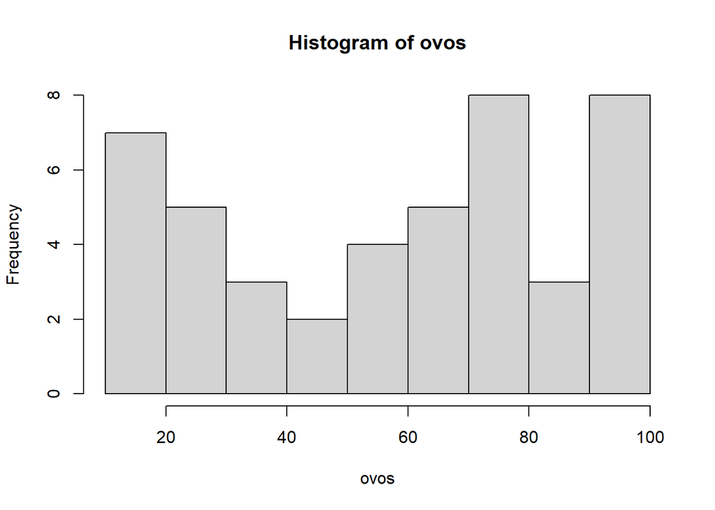

```r
hist(ovos)
```

### Representação gráfica dos quantiles

Pode auxiliar na escolha do modelo que a distribuição dos seus dados melhor se encaixa.

```
## [1] 32 42
```

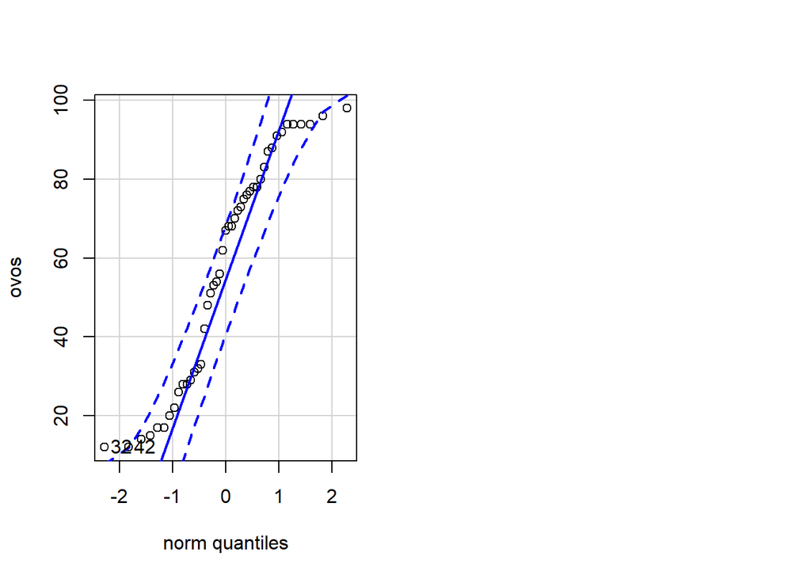

[figure not shown]

```r
par(mfrow=c(1,2)) # plot de dois gráficos na mesma folha
qqp(ovos, "norm") #quantile quantile plot da distribuição normal
```

## Parte 3. Análise para dados com distribuição Normal ou Gaussiana

### Vamos testar a distribuição para a variável **ovos**

- Distribuição Normal ou Gaussiana
  - Concentração de valores em torno de um valor central;
  - Simetria em torno do valor central;
  - Frequência pequena de valores muito extremos.

  A distribuição normal possui dois parâmetros, a média (μ), ou seja onde está centralizada e a variância (σ2>0) que descreve o seu grau de dispersão. Ou ainda o desvio padrão (σ). Cabe salientar que como qualquer outro modelo, dependendo dos parâmetros, teremos diferentes distribuições normais.

Aceitar  
H<sub>0</sub>: consistem em dizer que há normalidade nos dados - p > 0.05

H<sub>1</sub>: que não há - p < 0.05

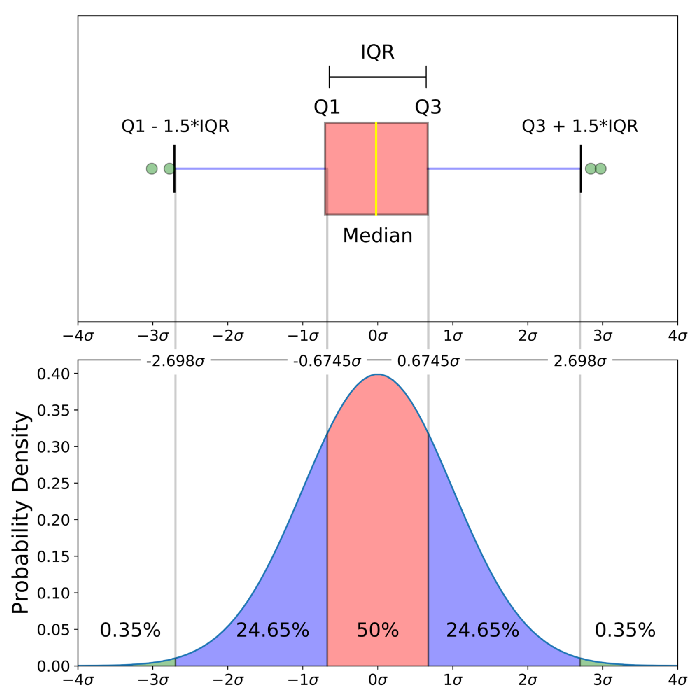

```r
shapiro.test(ovos)
```

```
##
##  Shapiro-Wilk normality test
##
## data:  ovos
## W = 0.90943, p-value = 0.001888
```

### Vamos testar a homocedasticidade para **ovos**

Homocedasticidade é o termo para designar variância constante dos erros experimentais. *Cada nível tem sua variação em torno da média, se estes apresentam grande variação, mostra que os dados não são **homogêneos**.*

Quando *p-valor* for **menor** que o nível de significância escolhido para o teste (em geral, convencionado em 0,05), rejeita-se a H<sub>0</sub> e aceitamos hipótese alternativa, assumindo a **desigualdade das variâncias**. Caso ele seja **maior** que o nível de significância, concluímos que **as variâncias são constantes ou homogêneas**.

```r
bartlett.test(ovos ~ Dieta, data = dados)
```

```
##
##  Bartlett test of homogeneity of variances
##
## data:  ovos by Dieta
## Bartlett's K-squared = 7.5519, df = 2, p-value = 0.02291
```

### Boxplot

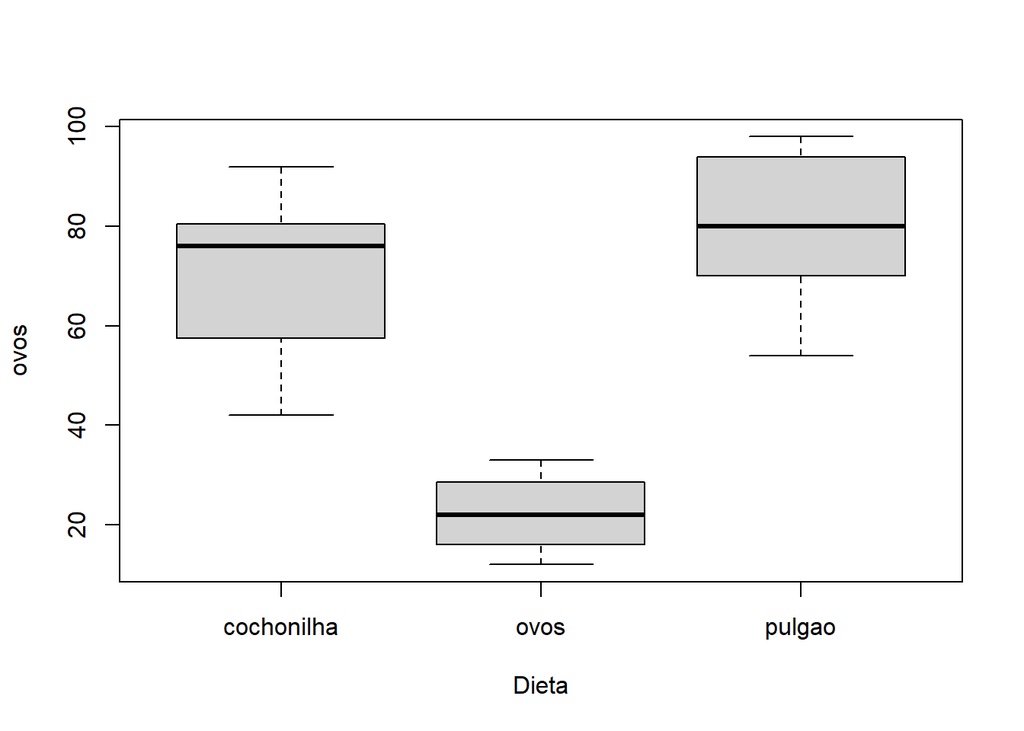

```r
boxplot(ovos~Dieta)
```

### *ANOVA*

```r
modelo1<-aov(ovos~Dieta)
anova(modelo1,test="F")
```

```
## Analysis of Variance Table
##
## Response: ovos
##           Df  Sum Sq Mean Sq F value    Pr(>F)
## Dieta      2 28704.4 14352.2  80.227 4.523e-15 ***
## Residuals 42  7513.6   178.9
## ---
## Signif. codes:  0 '***' 0.001 '**' 0.01 '*' 0.05 '.' 0.1 ' ' 1
```

```r
Tukey<-TukeyHSD(x=modelo1,'Dieta', conf.level = 0.95)
Tukey
```

```
##   Tukey multiple comparisons of means
##     95% family-wise confidence level
##
## Fit: aov(formula = ovos ~ Dieta)
##
## $Dieta
##                    diff        lwr       upr     p adj
## ovos-cochonilha   -48.0 -59.865459 -36.13454 0.0000000
## pulgao-cochonilha   9.8  -2.065459  21.66546 0.1230937
## pulgao-ovos        57.8  45.934541  69.66546 0.0000000
```

> Extra: Shapiro-Wilk de cada nível dentro do grupo

```r
library(RVAideMemoire)
byf.shapiro(ovos~Dieta, data=dados)
```

```
##
##  Shapiro-Wilk normality tests
##
## data:  ovos by Dieta
##
##                 W p-value
## cochonilha 0.9375 0.35216
## ovos       0.9083 0.12737
## pulgao     0.8939 0.07693 .
## ---
## Signif. codes:  0 '***' 0.001 '**' 0.01 '*' 0.05 '.' 0.1 ' ' 1
```

## Análise descritiva

### Médias e erros

```r
medias<-tapply(ovos, Dieta, mean)
medias
```

```
## cochonilha       ovos     pulgao
##       70.4       22.4       80.2
```

```r
erro<-tapply(ovos, Dieta, sd)/sqrt(tapply(ovos, Dieta, length))
erro
```

```
## cochonilha       ovos     pulgao
##   4.128646   1.956187   3.860915
```

### Representação em Barplot

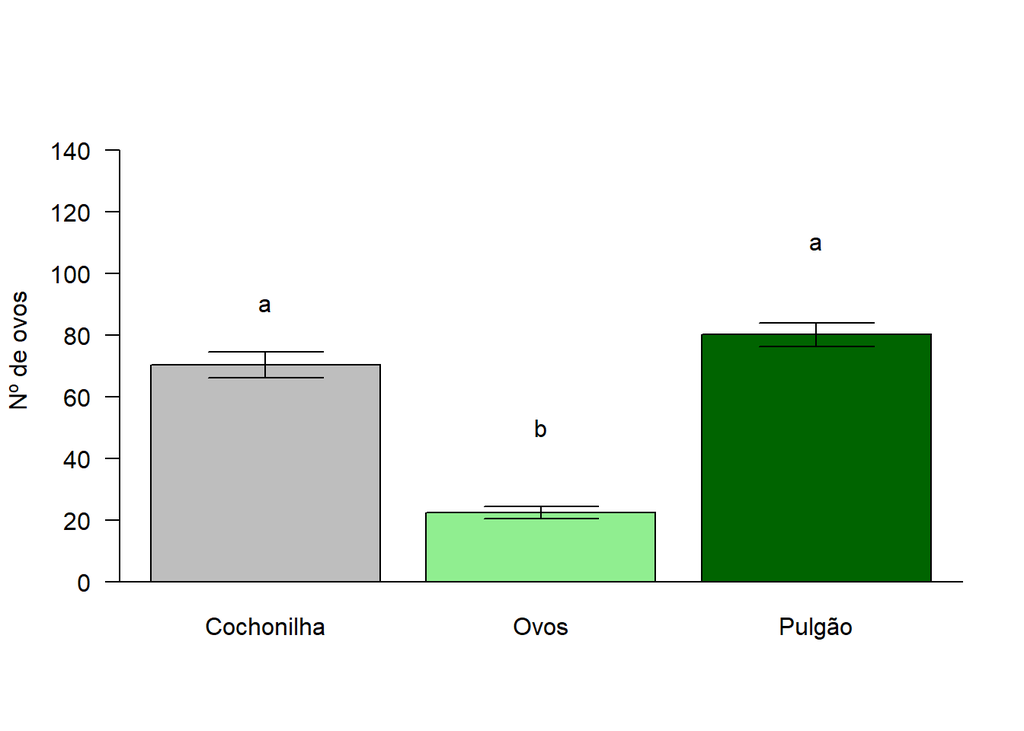

```r
barplot2(medias,
 plot.ci=T,
 ci.u=medias+erro,
 ci.l=medias-erro,
 ylab="Nº de ovos",
 ylim=c(0,150),
 las=1,
 names.arg = c("Cochonilha","Ovos", "Pulgão"),
 col=c("gray","lightgreen", "darkgreen"))
 text(0.7,90,"a")
 text(1.9,50,"b")
 text(3.1,110,"a")
abline(h=0)
```

Livro R markdown [^2]. [Livro:](https://bookdown.org/yihui/bookdown/)

**Lembrar de fazer o `detach` para desafixar a tabela do programa.**

**Risco de “chamar” variável de outra tabela por ter nomes idênticos.**

> Quem souber transformar para Box-Cox, log ou sqrt fique à vontade também ou ver se a distribuição se encaixa melhor para Gamma.

Vem aí:

# Dia 3 - E quando nossos dados não apresentam distribuição normal?

- GLM - Distribuição Poisson
- GLM - Distribuição Binomial Negativa.
- Análise de contraste.

## Premissas para análises paramétricas dos dados:

- Distribuição normal;
- Variância constante
- Independência

## Existem várias situações onde os dados não apresentam essas características

- As respostas são binária(0,1), ou contávéis
- Apresentam distribuição não-normal [^3].

### Soluções para esse “problema”

#### Transformação dos dados

- Induz aproximação para normalidade;
- Estabiliza a variância;
- **não é garantia que uma transformação irão resolver esses problemas: pode haver uma troca entre homocedasticidade e linearidade e necessidade de aplicação de outro modelo** [^4].

#### Modelos lineares generalizados (GLM)

- Os pesquisadores biológicos podem especificar diretamente a distribuição de erros e a relação entre a média e a variância;
  - Erro binomial (binário)
  - Erro Poisson (contagens por unidade) [^5].

### GLM Gaussian

```r
gauss=glm(ovos~1)
gauss1=glm(ovos~Dieta) #modelo
anova(gauss,gauss1,test="F")
```

```
## Analysis of Deviance Table
##
## Model 1: ovos ~ 1
## Model 2: ovos ~ Dieta
##   Resid. Df Resid. Dev Df Deviance      F    Pr(>F)
## 1        44      36218
## 2        42       7514  2    28704 80.227 4.523e-15 ***
## ---
## Signif. codes:  0 '***' 0.001 '**' 0.01 '*' 0.05 '.' 0.1 ' ' 1
```

`gauss` é o modelo nulo (sem efeito do tratamento)  
`gauss1` é o modelo “mais completo” com efeito do tratamento = *Dieta*

Os modelos apresentaram diferença entre si, ou seja, a *Dieta* apresentou efeito na análise

#### *ANOVA*

```r
anova(gauss1,test="F")
```

```
## Analysis of Deviance Table
##
## Model: gaussian, link: identity
##
## Response: ovos
##
## Terms added sequentially (first to last)
##
##
##       Df Deviance Resid. Df Resid. Dev      F    Pr(>F)
## NULL                     44      36218
## Dieta  2    28704        42       7514 80.227 4.523e-15 ***
## ---
## Signif. codes:  0 '***' 0.001 '**' 0.01 '*' 0.05 '.' 0.1 ' ' 1
```

```r
#Podemos observar que na propria tabela já descreve que o modelo é Gaussian
```

A Análise de Deviância do `gauss1` mostrou que a *Dieta* afetou signficativamente a fecundidade de *Eriopis connexa*.

```r
summary(gauss1)
```

```
##
## Call:
## glm(formula = ovos ~ Dieta)
##
## Deviance Residuals:
##    Min      1Q  Median      3Q     Max
##  -28.4    -8.4    -0.2     9.6    21.6
##
## Coefficients:
##             Estimate Std. Error t value Pr(>|t|)
## (Intercept)   70.400      3.453  20.385  < 2e-16 ***
## Dietaovos    -48.000      4.884  -9.828 1.88e-12 ***
## Dietapulgao    9.800      4.884   2.007   0.0513 .
## ---
## Signif. codes:  0 '***' 0.001 '**' 0.01 '*' 0.05 '.' 0.1 ' ' 1
##
## (Dispersion parameter for gaussian family taken to be 178.8952)
##
##     Null deviance: 36218.0  on 44  degrees of freedom
## Residual deviance:  7513.6  on 42  degrees of freedom
## AIC: 366.01
##
## Number of Fisher Scoring iterations: 2
```

```r
#Residual deviance:  7513.6  on 42  degrees of freedom

7513.6/42
```

```
## [1] 178.8952
```

### Modelagem para dados contáveis que não apresentam distribuição normal

### GLM Poisson [^6].

```r
ovi=glm(ovos~1,poisson) #modelo nulo
ovi1=glm(ovos~Dieta,poisson) #modelo completo'
# Adicionar o tipo de distribuição no modelo
anova(ovi,ovi1,test="Chisq") #Teste qui-quadrado
```

```
## Analysis of Deviance Table
##
## Model 1: ovos ~ 1
## Model 2: ovos ~ Dieta
##   Resid. Df Resid. Dev Df Deviance  Pr(>Chi)
## 1        44     710.03
## 2        42     130.51  2   579.52 < 2.2e-16 ***
## ---
## Signif. codes:  0 '***' 0.001 '**' 0.01 '*' 0.05 '.' 0.1 ' ' 1
```

#### *ANODEV*

```r
anova(ovi1,test="Chisq")
```

```
## Analysis of Deviance Table
##
## Model: poisson, link: log
##
## Response: ovos
##
## Terms added sequentially (first to last)
##
##
##       Df Deviance Resid. Df Resid. Dev  Pr(>Chi)
## NULL                     44     710.03
## Dieta  2   579.52        42     130.51 < 2.2e-16 ***
## ---
## Signif. codes:  0 '***' 0.001 '**' 0.01 '*' 0.05 '.' 0.1 ' ' 1
```

```r
# Análise de deviância do modelo completo
```

Tabela com os dados que devem ser adicionados aos resultados

#### Análise de resíduos

Como sabemos se os dados obedecem a distribuição Poisson?  
- qqp (quantile-quantile plot)  
- plot quantile  
- “Envelope”  
- Análise pelo resíduo da deviancia e seu grau de liberdade

```r
#poisson <- fitdistr(ovos, "Poisson") # calculo do parâmetro lambda utilizado para Poisson
#poisson
#qqp(ovos, "pois", lambda=poisson$estimate)
```

Plot quantile

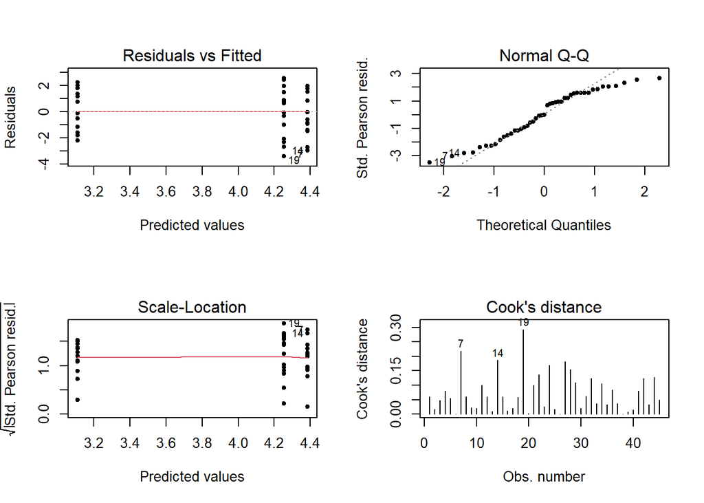

```r
par(mfrow=c(2,2)) #linhas,colunas
plot(ovi1,which=c(1:4),pch=20)
```

Envelope

Precisa instalar o pacote `RT4bio`

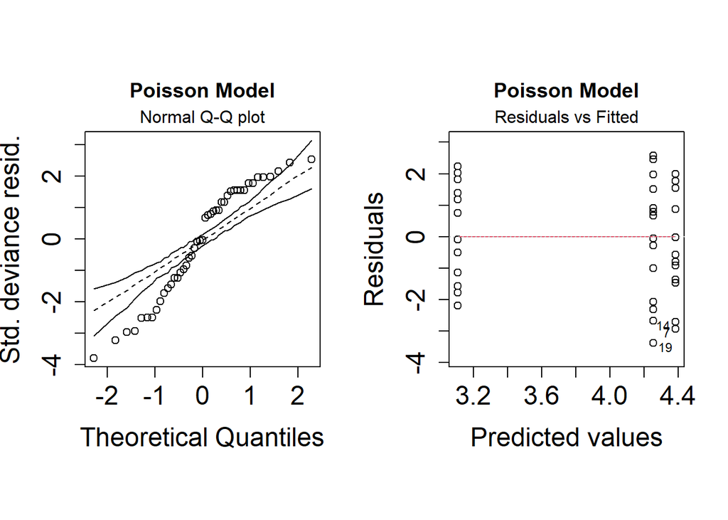

```r
library(RT4Bio)
rdiagnostic(ovi1)
```

Análise de resíduo

```r
summary(ovi1)
```

```
##
## Call:
## glm(formula = ovos ~ Dieta, family = poisson)
##
## Deviance Residuals:
##     Min       1Q   Median       3Q      Max
## -3.6622  -1.3992  -0.0223   1.4997   2.4571
##
## Coefficients:
##             Estimate Std. Error z value Pr(>|z|)
## (Intercept)  4.25419    0.03077 138.245   <2e-16 ***
## Dietaovos   -1.14513    0.06264 -18.283   <2e-16 ***
## Dietapulgao  0.13033    0.04217   3.091    0.002 **
## ---
## Signif. codes:  0 '***' 0.001 '**' 0.01 '*' 0.05 '.' 0.1 ' ' 1
##
## (Dispersion parameter for poisson family taken to be 1)
##
##     Null deviance: 710.03  on 44  degrees of freedom
## Residual deviance: 130.51  on 42  degrees of freedom
## AIC: 394.08
##
## Number of Fisher Scoring iterations: 4
```

```r
130.51/42
```

```
## [1] 3.107381
```

### GLM Binomial Negativa

```r
m0b=glm.nb(ovos~1) #binomial negativa glm.nb
m1b=glm.nb(ovos~Dieta)
anova(m0b,m1b)
```

```
## Likelihood ratio tests of Negative Binomial Models
##
## Response: ovos
##   Model     theta Resid. df    2 x log-lik.   Test    df LR stat. Pr(Chi)
## 1     1  3.292398        44       -431.7328
## 2 Dieta 28.735836        42       -352.6557 1 vs 2     2 79.07712       0
```

#### *ANODEV*

```r
anova(m1b)
```

```
## Analysis of Deviance Table
##
## Model: Negative Binomial(28.7358), link: log
##
## Response: ovos
##
## Terms added sequentially (first to last)
##
##
##       Df Deviance Resid. Df Resid. Dev  Pr(>Chi)
## NULL                     44    266.183
## Dieta  2   217.98        42     48.201 < 2.2e-16 ***
## ---
## Signif. codes:  0 '***' 0.001 '**' 0.01 '*' 0.05 '.' 0.1 ' ' 1
```

#### Análise de resíduo

##### plot quantile

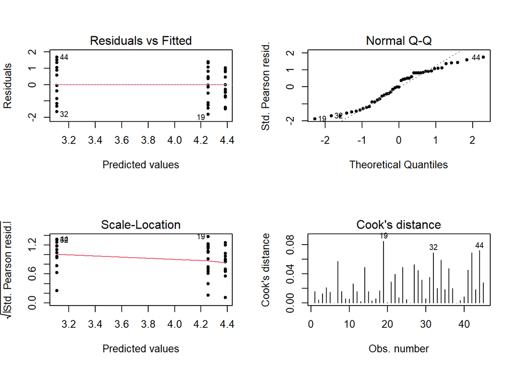

```r
par(mfrow=c(2,2))
plot(m1b,which=c(1:4),pch=20)
```

##### Envelope

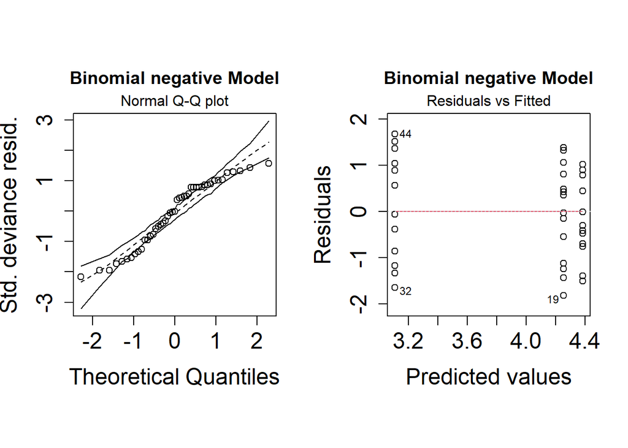

```r
library(RT4Bio)
rdiagnostic(m1b)
```

##### Análise do resíduo

```r
summary(m1b)
```

```
##
## Call:
## glm.nb(formula = ovos ~ Dieta, init.theta = 28.73583639, link = log)
##
## Deviance Residuals:
##      Min        1Q    Median        3Q       Max
## -2.08906  -0.91090  -0.01148   0.77062   1.52053
##
## Coefficients:
##             Estimate Std. Error z value Pr(>|z|)
## (Intercept)  4.25419    0.05716  74.430   <2e-16 ***
## Dietaovos   -1.14513    0.09254 -12.375   <2e-16 ***
## Dietapulgao  0.13033    0.08011   1.627    0.104
## ---
## Signif. codes:  0 '***' 0.001 '**' 0.01 '*' 0.05 '.' 0.1 ' ' 1
##
## (Dispersion parameter for Negative Binomial(28.7358) family taken to be 1)
##
##     Null deviance: 266.183  on 44  degrees of freedom
## Residual deviance:  48.201  on 42  degrees of freedom
## AIC: 360.66
##
## Number of Fisher Scoring iterations: 1
##
##
##               Theta:  28.74
##           Std. Err.:  9.98
##
##  2 x log-likelihood:  -352.656
```

```r
48.201/42
```

```
## [1] 1.147643
```

Podemos aceitar a distribuição Binomial Negativa para os nossos dados, pois é onde o erro tem menor variação.

### Análise de contraste para separação das médias

- Vamos tentar juntas os níveis/tratamentos que tem médias mais próximas
- Criar modelos e compará-los  
  - Se existe diferença entre os modelos os níveis são diferentes;  
  - Se não há diferença entre os modelos (*P*>0.05) os tratamentos não apresentam diferença.

```r
Dieta= as.factor(Dieta)
medias=tapply(ovos, Dieta, mean)
medias
```

```
## cochonilha       ovos     pulgao
##       70.4       22.4       80.2
```

```r
sort(medias)
```

```
##       ovos cochonilha     pulgao
##       22.4       70.4       80.2
```

Vamos tentar juntas os níveis/tratamentos que tem médias mais próximas

```r
dieta2=Dieta
dieta2
```

```
##  [1] pulgao     pulgao     pulgao     pulgao     pulgao     pulgao
##  [7] pulgao     pulgao     pulgao     pulgao     pulgao     pulgao
## [13] pulgao     pulgao     pulgao     cochonilha cochonilha cochonilha
## [19] cochonilha cochonilha cochonilha cochonilha cochonilha cochonilha
## [25] cochonilha cochonilha cochonilha cochonilha cochonilha cochonilha
## [31] ovos       ovos       ovos       ovos       ovos       ovos
## [37] ovos       ovos       ovos       ovos       ovos       ovos
## [43] ovos       ovos       ovos
## Levels: cochonilha ovos pulgao
```

```r
levels(dieta2)[1]= "cocpug"
levels(dieta2)[3]= "cocpug"
levels(dieta2)
```

```
## [1] "cocpug" "ovos"
```

Criando modelo com os níveis *cochonilha* e *pulgão* amalgamados

```r
m2b=glm.nb(ovos~dieta2)
anova(m1b,m2b)
```

```
## Likelihood ratio tests of Negative Binomial Models
##
## Response: ovos
##    Model    theta Resid. df    2 x log-lik.   Test    df LR stat.   Pr(Chi)
## 1 dieta2 25.80347        43       -355.1984
## 2  Dieta 28.73584        42       -352.6557 1 vs 2     1 2.542658 0.1108081
```

*P*= 0.11, então os modelos podem ser amalgamados;  
Cochonilhas e pulgão não apresentam diferença significativa;  
Poderiamos amalgamar *Dieta* ovos e cochonilhas ?

```r
dieta3=Dieta
dieta3
```

```
##  [1] pulgao     pulgao     pulgao     pulgao     pulgao     pulgao
##  [7] pulgao     pulgao     pulgao     pulgao     pulgao     pulgao
## [13] pulgao     pulgao     pulgao     cochonilha cochonilha cochonilha
## [19] cochonilha cochonilha cochonilha cochonilha cochonilha cochonilha
## [25] cochonilha cochonilha cochonilha cochonilha cochonilha cochonilha
## [31] ovos       ovos       ovos       ovos       ovos       ovos
## [37] ovos       ovos       ovos       ovos       ovos       ovos
## [43] ovos       ovos       ovos
## Levels: cochonilha ovos pulgao
```

```r
levels(dieta3)[1]= "ovcoc"
levels(dieta3)[2]= "ovcoc"
levels(dieta3)
```

```
## [1] "ovcoc"  "pulgao"
```

```r
m3b=glm.nb(ovos~dieta3)
anova(m1b,m3b)
```

```
## Likelihood ratio tests of Negative Binomial Models
##
## Response: ovos
##    Model     theta Resid. df    2 x log-lik.   Test    df LR stat.      Pr(Chi)
## 1 dieta3  4.238422        43       -420.7146
## 2  Dieta 28.735836        42       -352.6557 1 vs 2     1 68.05887 1.110223e-16
```

Os modelos apresentam diferença significativa, não podemos amalgamálos.

Logo, podemos definir que temos as letras  
- Pulgão **a**  
- Cochonilha **a**  
- Ovos **b**

### Gráfico *Boxplot*

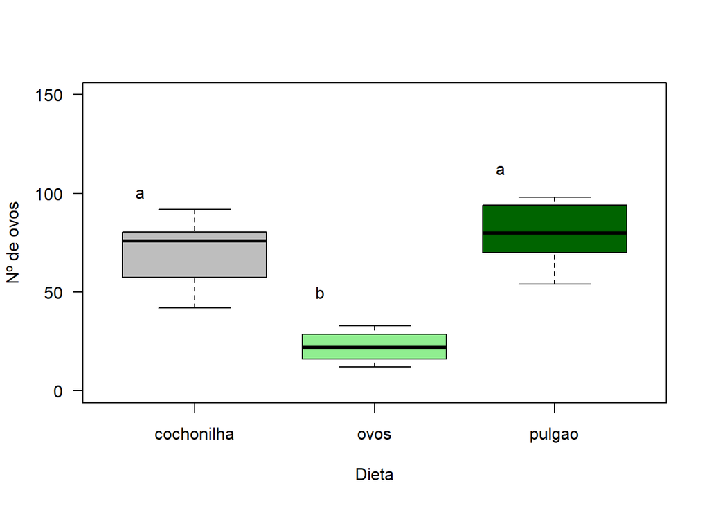

```r
boxplot(ovos~Dieta,
 ylab="Nº de ovos",
 ylim=c(0,150),
 las=1,
 names.arg = c("Cochonilha","Ovos", "Pulgão"),
 col=c("gray","lightgreen", "darkgreen"))
 text(0.7,100,"a")
 text(1.7,50,"b")
 text(2.7,112,"a")
```

#### Lembrar de fazer o `detach` para desafixar a tabela do programa

Risco de “chamar” variável de outra tabela por ter nomes identicos

```r
detach(dados)
```

Salvar documento `.docx` > Mostrar documento salvo

# Dia 4 - Porcentagem/ Presença e ausência.

- GLM Binomial – Fertilidade + Análise de contraste
- GLM Binomial - Sobrevivência [^7].

### Carregar os dados

```r
dados<-read.table("Dados_CursoR.txt",h=T)
attach(dados)
head(dados)
```

```
##    Dieta rep ovos larvas survive censor total
## 1 pulgao cr1   94     76      30      0     1
## 2 pulgao cr2   73     50      30      0     1
## 3 pulgao cr3   68     58      20      1     1
## 4 pulgao cr4   96     72      30      0     1
## 5 pulgao cr5   67     40      22      1     1
## 6 pulgao cr7   80     46      20      1     1
```

### Construção dos modelos

- (parcial/total)
- wights = total
- família binomial

```r
mb0=glm(larvas/ovos~1,weights = ovos,binomial) #modelo nulo, aleatório
mb1=glm(larvas/ovos~Dieta,weights = ovos,binomial) #modelo completo, com efeito do tratament (Dieta)
anova(mb0,mb1,test="Chisq")
```

```
## Analysis of Deviance Table
##
## Model 1: larvas/ovos ~ 1
## Model 2: larvas/ovos ~ Dieta
##   Resid. Df Resid. Dev Df Deviance  Pr(>Chi)
## 1        44     751.53
## 2        42     102.61  2   648.92 < 2.2e-16 ***
## ---
## Signif. codes:  0 '***' 0.001 '**' 0.01 '*' 0.05 '.' 0.1 ' ' 1
```

Análise de deviancia

```r
anova(mb1,test="Chisq") #tabela da ANOVA
```

```
## Analysis of Deviance Table
##
## Model: binomial, link: logit
##
## Response: larvas/ovos
##
## Terms added sequentially (first to last)
##
##
##       Df Deviance Resid. Df Resid. Dev  Pr(>Chi)
## NULL                     44     751.53
## Dieta  2   648.92        42     102.61 < 2.2e-16 ***
## ---
## Signif. codes:  0 '***' 0.001 '**' 0.01 '*' 0.05 '.' 0.1 ' ' 1
```

Teste de sobredispersão - (Envelope)

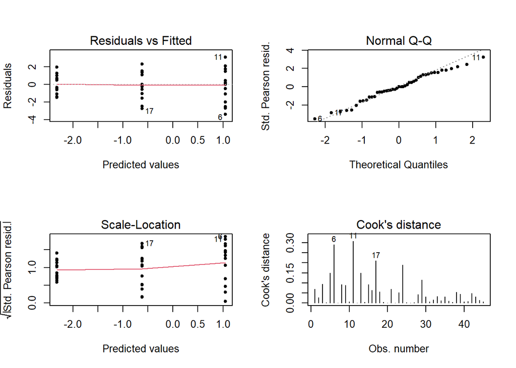

```r
par(mfrow=c(2,2))
plot(mb1,which=c(1:4),pch=20)
```

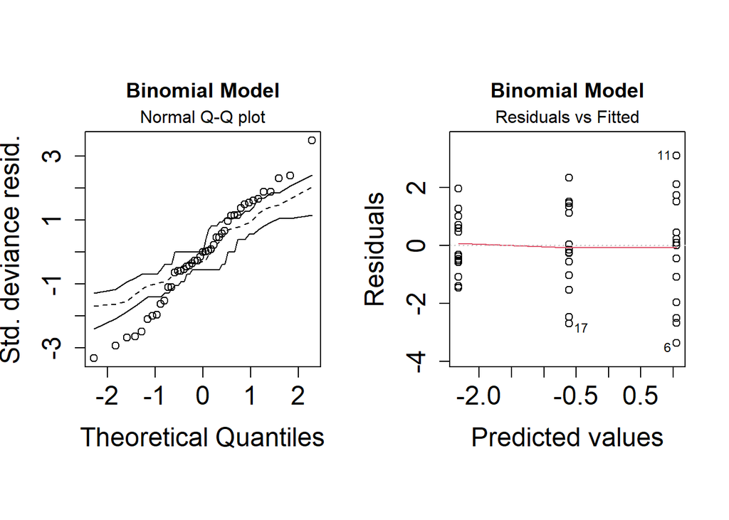

```r
rdiagnostic(mb1)
```

Informações para o texto dos resultados

```r
summary(mb1)
```

```
##
## Call:
## glm(formula = larvas/ovos ~ Dieta, family = binomial, weights = ovos)
##
## Deviance Residuals:
##     Min       1Q   Median       3Q      Max
## -3.2086  -1.0590   0.0015   1.1270   3.3408
##
## Coefficients:
##             Estimate Std. Error z value Pr(>|z|)
## (Intercept) -0.61322    0.06446  -9.513   <2e-16 ***
## Dietaovos   -1.70917    0.20188  -8.466   <2e-16 ***
## Dietapulgao  1.66256    0.09210  18.051   <2e-16 ***
## ---
## Signif. codes:  0 '***' 0.001 '**' 0.01 '*' 0.05 '.' 0.1 ' ' 1
##
## (Dispersion parameter for binomial family taken to be 1)
##
##     Null deviance: 751.53  on 44  degrees of freedom
## Residual deviance: 102.61  on 42  degrees of freedom
## AIC: 276.43
##
## Number of Fisher Scoring iterations: 4
```

```r
102.61/42
```

```
## [1] 2.443095
```

### Binomial Negativa

Correção

```r
help0=glm.nb((larvas/ovos)*100~1) #binomial negativa glm.nb
help1=glm.nb((larvas/ovos)*100~Dieta)
anova(help0,help1)
```

```
## Likelihood ratio tests of Negative Binomial Models
##
## Response: (larvas/ovos) * 100
##   Model     theta Resid. df    2 x log-lik.   Test    df LR stat.      Pr(Chi)
## 1     1  1.259316        44       -420.0046
## 2 Dieta 16.245908        42       -352.9661 1 vs 2     2 67.03848 2.775558e-15
```

Análise de deviancia

```r
anova(help1)
```

```
## Analysis of Deviance Table
##
## Model: Negative Binomial(16.2459), link: log
##
## Response: (larvas/ovos) * 100
##
## Terms added sequentially (first to last)
##
##
##       Df Deviance Resid. Df Resid. Dev  Pr(>Chi)
## NULL                     44     355.91
## Dieta  2   275.09        42      80.82 < 2.2e-16 ***
## ---
## Signif. codes:  0 '***' 0.001 '**' 0.01 '*' 0.05 '.' 0.1 ' ' 1
```

Análise de dispersão

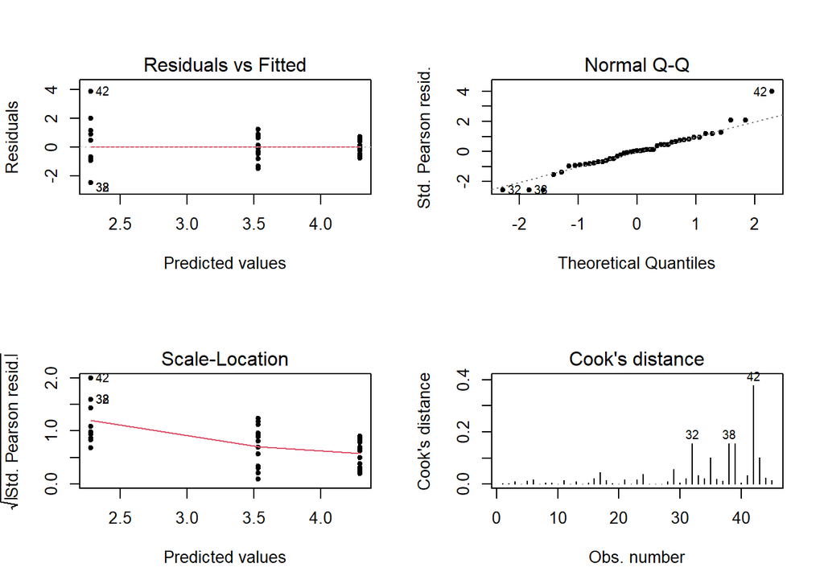

```r
par(mfrow=c(2,2))
plot(help1,which=c(1:4),pch=20)
```

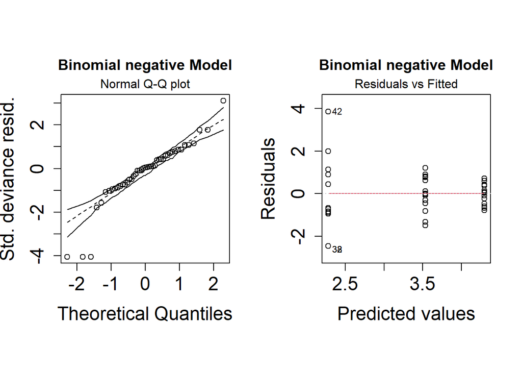

```r
rdiagnostic(help1)
```

```r
summary(help1)
```

```
##
## Call:
## glm.nb(formula = (larvas/ovos) * 100 ~ Dieta, init.theta = 16.24590808,
##     link = log)
##
## Deviance Residuals:
##     Min       1Q   Median       3Q      Max
## -3.9113  -0.7196   0.0375   0.5957   2.9939
##
## Coefficients:
##             Estimate Std. Error z value Pr(>|z|)
## (Intercept)   3.5324     0.0778  45.406  < 2e-16 ***
## Dietaovos    -1.2532     0.1303  -9.617  < 2e-16 ***
## Dietapulgao   0.7623     0.1052   7.247 4.26e-13 ***
## ---
## Signif. codes:  0 '***' 0.001 '**' 0.01 '*' 0.05 '.' 0.1 ' ' 1
##
## (Dispersion parameter for Negative Binomial(16.2459) family taken to be 1)
##
##     Null deviance: 355.910  on 44  degrees of freedom
## Residual deviance:  80.824  on 42  degrees of freedom
## AIC: 360.97
##
## Number of Fisher Scoring iterations: 1
##
##
##               Theta:  16.25
##           Std. Err.:  8.94
##
##  2 x log-likelihood:  -352.966
```

### Análise de residuos

Residual deviance: 80.824 on 42 degrees of freedom

```r
80.824/42
```

```
## [1] 1.924381
```

### Análise descritiva dos dados

```r
media<-tapply((larvas/ovos)*100,Dieta,mean)
media
```

```
## cochonilha       ovos     pulgao
##  34.207814   9.769265  73.316935
```

```r
erro<-tapply((larvas/ovos)*100,Dieta, sd)/sqrt(tapply((larvas/ovos)*100,Dieta, length))
erro
```

```
## cochonilha       ovos     pulgao
##   2.122228   1.891505   2.453464
```

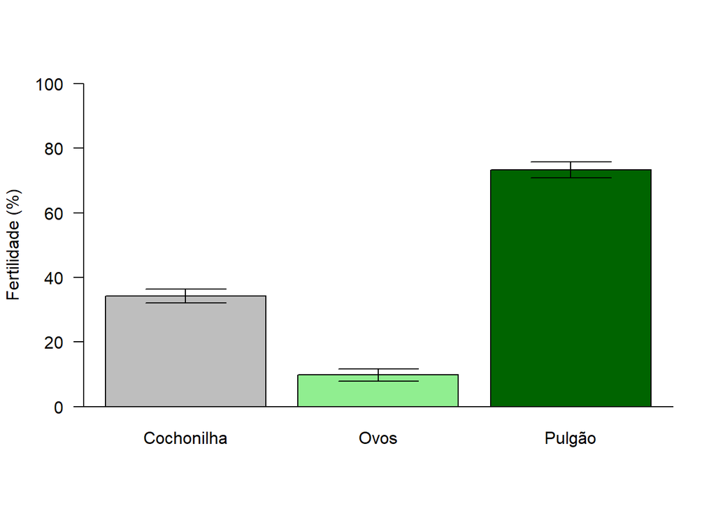

```r
barplot2(media,
 plot.ci=T,
 ci.u=media+erro,
 ci.l=media-erro,
 ylim=c(0,100),
 ylab="Fertilidade (%)",
  names.arg = c("Cochonilha","Ovos", "Pulgão"),
 col=c("gray","lightgreen", "darkgreen"),
 las=1
 )
abline(h=0)
```

### Dados Binomiais de Presença e ausência (0 ou 1)

Análise binomial não é a mais recomendada para análise de sobrevivência. Esta é uma característica (mortalidade) que é avaliada e acompanhada ao longo do tempo e são utilizadas outras ferramentas/distribuições (Weibull e Kruskal-Wallis).  
Então a pergunta aqui é:  
Qual a taxa de sobrevivência no final dos dias de observação?  
Contrução do modelo para observação do efeito do tratamento

```r
m0=glm(censor/total~1,weights = total,binomial)
pre1=glm(censor/total~Dieta,weights = total,binomial) #modelo
anova(m0,pre1,test="Chisq")
```

```
## Analysis of Deviance Table
##
## Model 1: censor/total ~ 1
## Model 2: censor/total ~ Dieta
##   Resid. Df Resid. Dev Df Deviance Pr(>Chi)
## 1        44     61.827
## 2        42     49.905  2   11.921 0.002578 **
## ---
## Signif. codes:  0 '***' 0.001 '**' 0.01 '*' 0.05 '.' 0.1 ' ' 1
```

Análise de deviancia do modelo com efeito do tratamento

```r
anova(pre1,test="Chisq")
```

```
## Analysis of Deviance Table
##
## Model: binomial, link: logit
##
## Response: censor/total
##
## Terms added sequentially (first to last)
##
##
##       Df Deviance Resid. Df Resid. Dev Pr(>Chi)
## NULL                     44     61.827
## Dieta  2   11.921        42     49.905 0.002578 **
## ---
## Signif. codes:  0 '***' 0.001 '**' 0.01 '*' 0.05 '.' 0.1 ' ' 1
```

Análise de sobredispersão

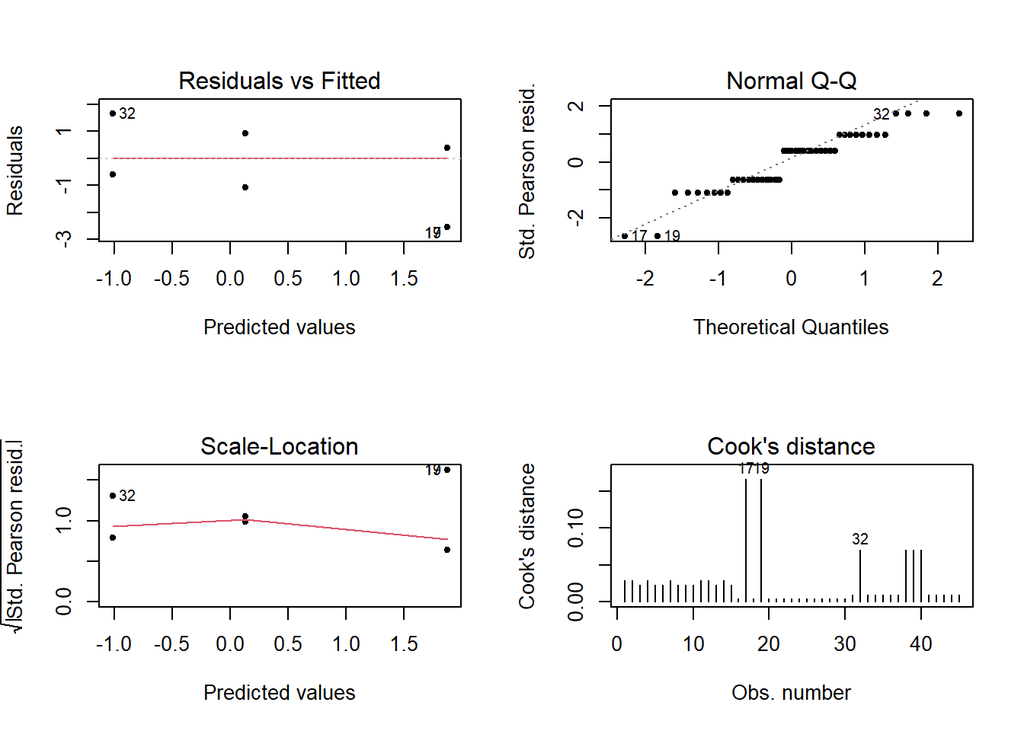

```r
par(mfrow=c(2,2))
plot(pre1,which=c(1:4),pch=20)
```

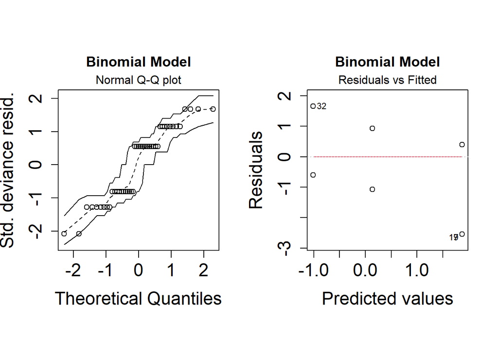

```r
rdiagnostic(pre1)
```

Apresentação dos dados para os resultados

```r
summary(pre1)
```

```
##
## Call:
## glm(formula = censor/total ~ Dieta, family = binomial, weights = total)
##
## Deviance Residuals:
##     Min       1Q   Median       3Q      Max
## -2.0074  -0.7876   0.5350   1.1213   1.6259
##
## Coefficients:
##             Estimate Std. Error z value Pr(>|z|)
## (Intercept)   1.8718     0.7596   2.464  0.01373 *
## Dietaovos    -2.8834     0.9580  -3.010  0.00262 **
## Dietapulgao  -1.7383     0.9191  -1.891  0.05859 .
## ---
## Signif. codes:  0 '***' 0.001 '**' 0.01 '*' 0.05 '.' 0.1 ' ' 1
##
## (Dispersion parameter for binomial family taken to be 1)
##
##     Null deviance: 61.827  on 44  degrees of freedom
## Residual deviance: 49.905  on 42  degrees of freedom
## AIC: 55.905
##
## Number of Fisher Scoring iterations: 4
```

### Análise de resíduos

Residual deviance: 49.905 on 42 degrees of freedom

```r
49.905/42
```

```
## [1] 1.188214
```

### Representação gráfica

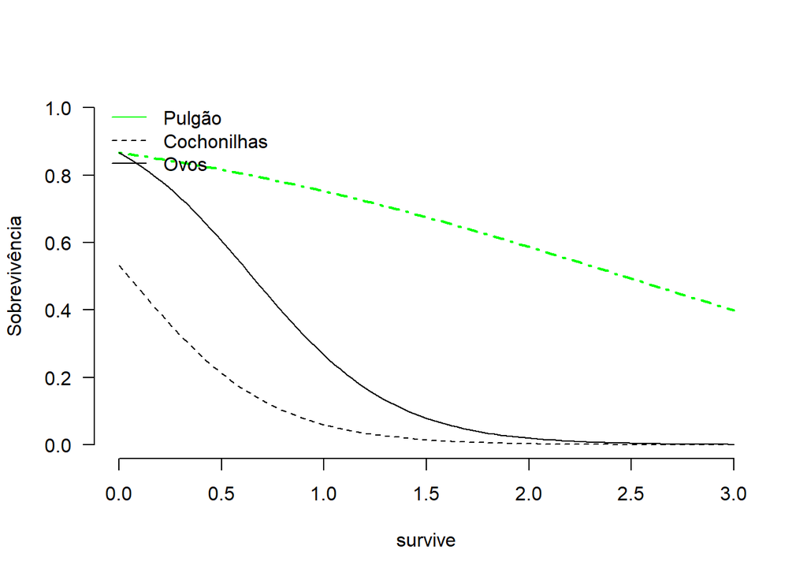

```r
plot((censor/total)~survive,
 las=1,
 ylab = "Sobrevivência",
 xlim=c(0, 3.0),
 bty= "n")

curve(exp(1.8718-0.7596*x)/(1+exp(1.8718-0.7596*x)), #curva de alto recurso
 add=T,
 lwd=2, #espessura da reta (aumenta o valor = aumenta a espessura)
 lty=4, #estilo da reta (1=contínuo; 2=tracejado)
 col="green")

curve(exp(1.8718-2.8834*x)/(1+exp(1.8718-2.8834*x)), #curva de alto recurso
 add=T,
 lwd=1, #espessura da reta (aumenta o valor = aumenta a espessura)
 lty=1, #estilo da reta (1=contínuo; 2=tracejado)
 col="black")

curve(exp(1.8718-2.8834*x -1.7383 )/(1+exp(1.8718-2.8834*x -1.7383 )), #curva baixo recurso
 add=T,
 lwd=1, #espessura da reta (aumenta o valor = aumenta a espessura)
 lty=2, #estilo da reta (1=contínuo; 2=tracejado)
 col="black")

legend("topleft", #posição da legenda
 c("Pulgão","Cochonilhas", "Ovos"), #informa os fatores
 lty = c(1, 2), #informa as linhas
 col=c("green", "black","black"), #informa a coloração
 bty = "n")
text(1060,0.2,"P < 0.001",font=3)
```

### Análise descritiva

```r
media2=tapply(censor/total,Dieta, mean)
media2
```

```
## cochonilha       ovos     pulgao
##  0.8666667  0.2666667  0.5333333
```

```r
erro2=tapply(censor/total,Dieta, sd)/sqrt(tapply(censor/total,Dieta,
length))
erro2
```

```
## cochonilha       ovos     pulgao
## 0.09085135 0.11818737 0.13333333
```

### Gráfico

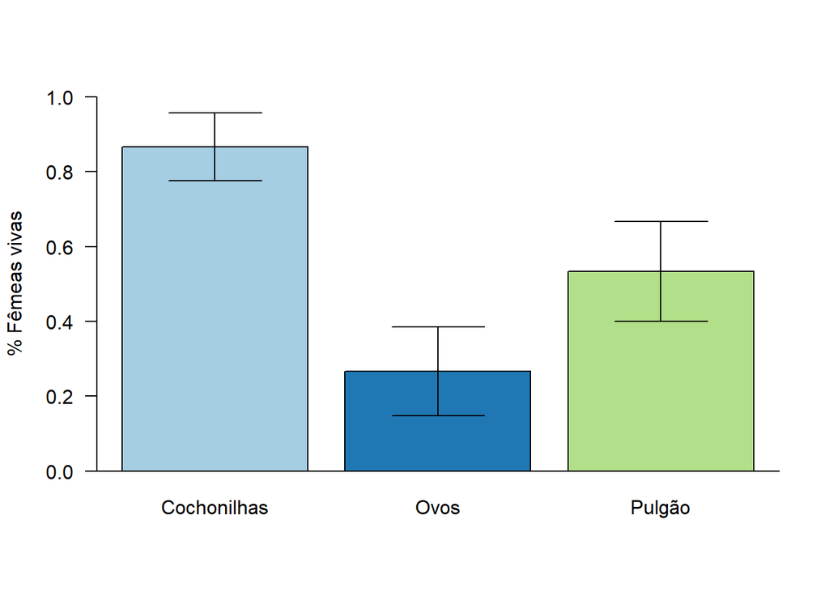

```r
#install.packages("RColorBrewer")
library(RColorBrewer)

cores <- brewer.pal(3, "Dark2")

cores2 <- brewer.pal(3, "Paired")
cores3 <- brewer.pal(10, "Set2")

library(ggplot2)
barplot2(media2,col=cores2,
 plot.ci=T,
 ci.u=media2+erro2,
 ci.l=media2-erro2,
 ylim=c(0.0,1.0),
 las=1,
 ylab="% Fêmeas vivas",
 names.arg = c("Cochonilhas","Ovos", "Pulgão"),
 )
abline(h=0)
```

Trabalhar com cores no R [^8].

```r
a <- c(1:10)
color <- colorRampPalette(c("red","yellow", "green"))
color(10)
```

```
##  [1] "#FF0000" "#FF3800" "#FF7100" "#FFAA00" "#FFE200" "#E2FF00" "#AAFF00"
##  [8] "#71FF00" "#38FF00" "#00FF00"
```

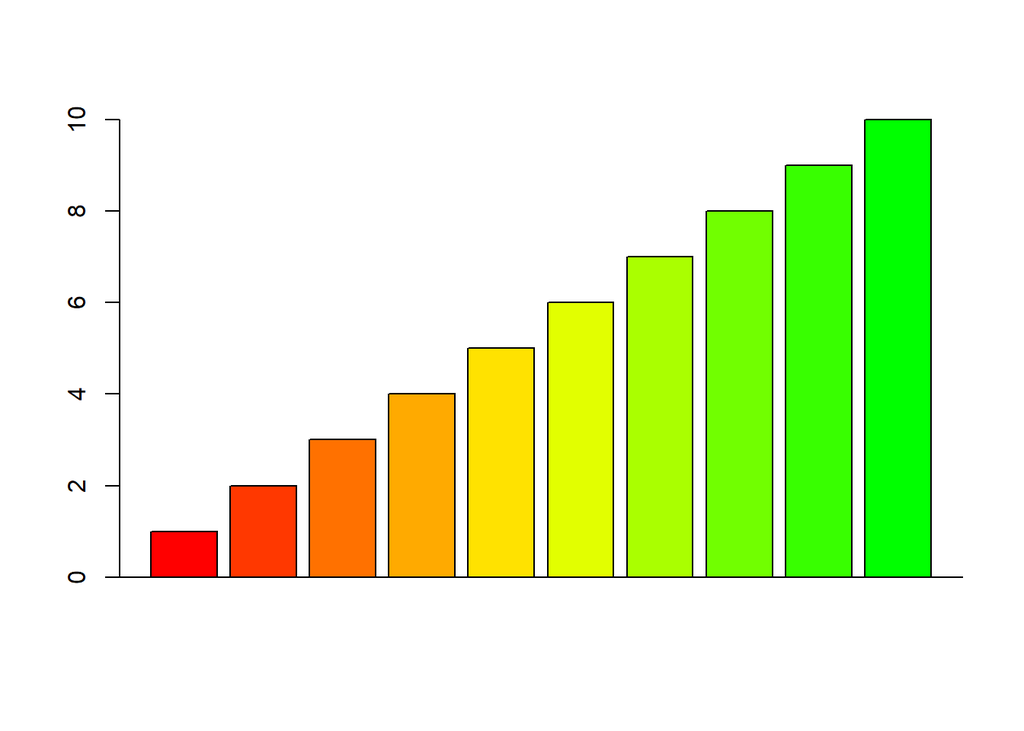

```r
barplot(a, col=color(10))
abline(h=0)
```

```r
b <- c(1:10)
corDegrade <- colorRampPalette(c("green","darkblue")) # Degradê de verde para azul
corDegrade(10)
```

```
##  [1] "#00FF00" "#00E20F" "#00C61E" "#00AA2E" "#008D3D" "#00714D" "#00555C"
##  [8] "#00386C" "#001C7B" "#00008B"
```

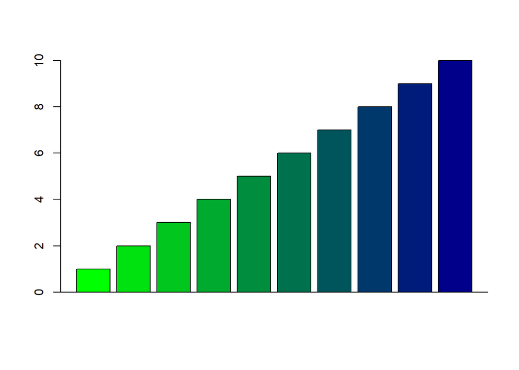

```r
barplot(b, col=corDegrade(10))
abline(h=0)
```

```r
detach (dados)
```

[^1]: Crawley, M. J. (2012). The R book. John Wiley & Sons.
[^2]: Xie, Y. (2016). Bookdown: authoring books and technical documents with R markdown. CRC Press.
[^3]: Demétrio, C. G., Hinde, J., & Moral, R. A. (2014). Models for overdispersed data in entomology. In Ecological modelling applied to entomology (pp. 219-259). Springer, Cham.
[^4]: St‐Pierre, A. P., Shikon, V., & Schneider, D. C. (2018). Count data in biology—Data transformation or model reformation?. Ecology and evolution, 8(6), 3077-3085.
[^5]: O’Hara, R., & Kotze, J. (2010). Do not log-transform count data. Nature Precedings, 1-1.
[^6]: Warton, D. I., Lyons, M., Stoklosa, J., & Ives, A. R. (2016). Three points to consider when choosing a LM or GLM test for count data. Methods in Ecology and Evolution, 7(8), 882-890.
[^7]: Se houver tempo.
[^8]: https://diegonogare.net/2015/09/trabalhar-com-cores-no-r/